# STA303 FINAL PROJECT

Li Quan Soh

2024-03-14

# 1 Research Question

I aim to investigate the the impact of unhealthy lifestyle, characterized by poor dietary habits and lack of exercises, on an individual’s predisposition to developing heart diseases. I will be using resting blood pressure, cholesterol level, and fasting blood sugar levels as physiological indicators of unhealthy lifestyle. Additionally, I will control for potential confounders in the form of age and gender and discuss their effects on my model. I will be modelling the relationships between these variables via GLM, specifically binomial logistic regression.

#### Why this question is different/ novel

While the aforementioned risk factors for heart diseases have been studied individually before, few studies have examined them collectively as indicators of lifestyle habits. Moreover, my research question addresses potential confounders, namely age and gender, to provide a more nuanced analysis of the association between lifestyle choice and heart disease development.

# 2 Peer-reviewed articles

1. Blood pressure and cholesterol as coronary heart disease risk factors:
- APA Citation:
  - Tyroler, H. A. (1971). Blood pressure and cholesterol as coronary heart disease risk factors. Archives of Internal Medicine, 128(6), 907–914. https://doi.org/10.1001/archinte.1971.00310240061007
  - In-text: (Tyroler, 1971)
- Research Question:
  - This article explores the relationship between blood pressure and serum cholesterol levels, both individually and in combination, and the incidence of coronary heart disease (CHD) in Georgia.
- Main Findings:
  - This study indicates that elevated levels of cholesterol and blood pressure significantly increases the risk of coronary heart disease. However, there are differences in CHD incidence rates between white and black men. As such, race may be a confounder for developing CHD.
- How it influence my work:
  - This study brings me confidence that cholesterol level and blood pressure are appropriate choices of exposure variables for my model. The study states that race is a potential confounder. However, race is not a variable in my dataset and I will ignore it.
2. Effects of lifestyle-related factors on ischemic heart disease according to body mass index and fasting blood glucose levels in Korean adults:
- APA Citation:
  - Shin, J., Ham, D., Shin, S., Choi, S. K., Paik, H.-Y., & Joung, H. (2019). Effects of lifestyle-related factors on ischemic heart disease according to body mass index and fasting blood glucose levels in Korean adults. PLOS ONE, 14(5). https://doi.org/10.1371/journal.pone.0216534
  - In-text: (Shin et al., 2019)
- Research Question:
  - This study aims to investigate the effect of lifestyle-related factors on ischemic heart disease (IHD). Body Mass Index (BMI) and fasting blood glucose (FBG) levels are used as metrics for lifestyle-related factors.
- Main Findings:
  - The risk of IHD is higher in people with more life-style related risk factors such as unbalanced diet, smoking, excessive alcohol consumption, and lack of physical activity. These life0style related risk factors are evident in the increase in BMI and FBG levels among Korean adults. The effects of these lifestyle-related risk factors on the rate of IHD is more pronounced in women than in men.
- How it influence my work:
  - This article suggests that fasting blood glucose level may be an appropriate exposure variable for my model. Since the effects of the risk factors on the incidence rate of IHD is stronger in women than in men, this means that sex is a potential confounder in my dataset. The article also considers age to be a potential confounder in their article too.Thus, I will be including age and sex as potential confounder.

3.Risk factors for coronary heart disease: implications of gender:

- APA Citation:
  - Roeters van Lennep, J., Westerveld, H., Erkelens, D., & E van der Wall, E. (2002). Risk factors for coronary heart disease: Implications of gender. Cardiovascular Research, 53(3), 538–549. https://doi.org/10.1016/s0008-6363(01)00388-1
  - In-text:(Roeters van Lennep et al., 2002)
- Research Question:
  - This study addresses whether cardiovascular risk factors, such as diabetes, high density lipoproteins levels etc may have different levels of impact depending on the sex of the individual (men or women).
- Main Findings:
  - The majority of the risk factors considered in the study show no important differences between sexes. However, diabetes, HDL (cholesterol) level, and triglycerides levels have been found to have greater impact on heart disease risk in women than in men. On the other hand, lipoprotein level may have greater impact on heart disease risk in men than in women.
- How it influence my work:
  - This paper considers diabetes and HDL level as risk factors for developing heart disease. Diabetes can be be measured by fasting blood glucose level. Thus, I will include fasting blood glucose level and cholesterol level as exposures in my model. Along with the 2nd paper, sex appears to be a strong potential confounding variable for my model.

# 3 Dataset Summary and Predictors Definition

Citation of my dataset:

fedesoriano. (2021). Heart Failure Prediction Dataset [Data set]. Kaggle. https://www.kaggle.com/fedesoriano/heart-failure-prediction.

#### Loading dataset

```r
dataset <- read.csv("heart.csv", header = TRUE, stringsAsFactors = TRUE)
str(dataset)
```

```
## 'data.frame':    918 obs. of  12 variables:
##  $ Age           : int  40 49 37 48 54 39 45 54 37 48 ...
##  $ Sex           : Factor w/ 2 levels "F","M": 2 1 2 1 2 2 1 2 2 1 ...
##  $ ChestPainType : Factor w/ 4 levels "ASY","ATA","NAP",..: 2 3 2 1 3 3 2 2 1 2 ...
##  $ RestingBP     : int  140 160 130 138 150 120 130 110 140 120 ...
##  $ Cholesterol   : int  289 180 283 214 195 339 237 208 207 284 ...
##  $ FastingBS     : int  0 0 0 0 0 0 0 0 0 0 ...
##  $ RestingECG    : Factor w/ 3 levels "LVH","Normal",..: 2 2 3 2 2 2 2 2 2 2 ...
##  $ MaxHR         : int  172 156 98 108 122 170 170 142 130 120 ...
##  $ ExerciseAngina: Factor w/ 2 levels "N","Y": 1 1 1 2 1 1 1 1 2 1 ...
##  $ Oldpeak       : num  0 1 0 1.5 0 0 0 0 1.5 0 ...
##  $ ST_Slope      : Factor w/ 3 levels "Down","Flat",..: 3 2 3 2 3 3 3 3 2 3 ...
##  $ HeartDisease  : int  0 1 0 1 0 0 0 0 1 0 ...
```

```r
head(dataset)
```

|  | Age | Sex | ChestPainType | RestingBP | Cholesterol | FastingBS | RestingECG | MaxHR | ExerciseAngina | Oldpeak | ST_Slope | HeartDisease |
| --- | --- | --- | --- | --- | --- | --- | --- | --- | --- | --- | --- | --- |
| 1 | 40 | M | ATA | 140 | 289 | 0 | Normal | 172 | N | 0.0 | Up | 0 |
| 2 | 49 | F | NAP | 160 | 180 | 0 | Normal | 156 | N | 1.0 | Flat | 1 |
| 3 | 37 | M | ATA | 130 | 283 | 0 | ST | 98 | N | 0.0 | Up | 0 |
| 4 | 48 | F | ASY | 138 | 214 | 0 | Normal | 108 | Y | 1.5 | Flat | 1 |
| 5 | 54 | M | NAP | 150 | 195 | 0 | Normal | 122 | N | 0.0 | Up | 0 |
| 6 | 39 | M | NAP | 120 | 339 | 0 | Normal | 170 | N | 0.0 | Up | 0 |

#### Predictors

*Outcome*

- Heart Disease
  - Variable name: HeartDisease
  - Variable Type: Categorical (Nominal)
  - 1: Have heart disease
  - 0: Do not have heart disease

*Confounders*

- Age
  - Variable name: Age
  - Variable Type: Numerical (Discrete)
- Sex
  - Variable name: Sex
  - Variable Type: Categorial (Nominal)
  - M: Male
  - F: Female

I am not considering the other variables as predictors because I am considering lifestyle choices and those are resulting data from diagnostic tools (ie. ECG), or health symptoms(ie chest pain and angina).

#### Missing Values & Duplicated Rows

```r
# Count the missing values for each column
sapply(dataset, function(x)sum(is.na(x)))
```

```
##            Age            Sex  ChestPainType      RestingBP    Cholesterol
##              0              0              0              0              0
##      FastingBS     RestingECG          MaxHR ExerciseAngina        Oldpeak
##              0              0              0              0              0
##       ST_Slope   HeartDisease
##              0              0
```

```r
# Check number of duplicated rows
sum(duplicated(dataset) | duplicated(dataset, fromLast = TRUE))
```

```
## [1] 0
```

There are no missing values or duplicated rows in my dataset.

# 4 Exploratory Data Analysis

#### Dataset Summary

```r
library(ggplot2)
# summary of dataset
summary(dataset)
```

```
##       Age        Sex     ChestPainType   RestingBP      Cholesterol
##  Min.   :28.00   F:193   ASY:496       Min.   :  0.0   Min.   :  0.0
##  1st Qu.:47.00   M:725   ATA:173       1st Qu.:120.0   1st Qu.:173.2
##  Median :54.00           NAP:203       Median :130.0   Median :223.0
##  Mean   :53.51           TA : 46       Mean   :132.4   Mean   :198.8
##  3rd Qu.:60.00                         3rd Qu.:140.0   3rd Qu.:267.0
##  Max.   :77.00                         Max.   :200.0   Max.   :603.0
##    FastingBS       RestingECG      MaxHR       ExerciseAngina    Oldpeak
##  Min.   :0.0000   LVH   :188   Min.   : 60.0   N:547          Min.   :-2.6000
##  1st Qu.:0.0000   Normal:552   1st Qu.:120.0   Y:371          1st Qu.: 0.0000
##  Median :0.0000   ST    :178   Median :138.0                  Median : 0.6000
##  Mean   :0.2331                Mean   :136.8                  Mean   : 0.8874
##  3rd Qu.:0.0000                3rd Qu.:156.0                  3rd Qu.: 1.5000
##  Max.   :1.0000                Max.   :202.0                  Max.   : 6.2000
##  ST_Slope    HeartDisease
##  Down: 63   Min.   :0.0000
##  Flat:460   1st Qu.:0.0000
##  Up  :395   Median :1.0000
##             Mean   :0.5534
##             3rd Qu.:1.0000
##             Max.   :1.0000
```

#### Individual Variable EDA

**Age**

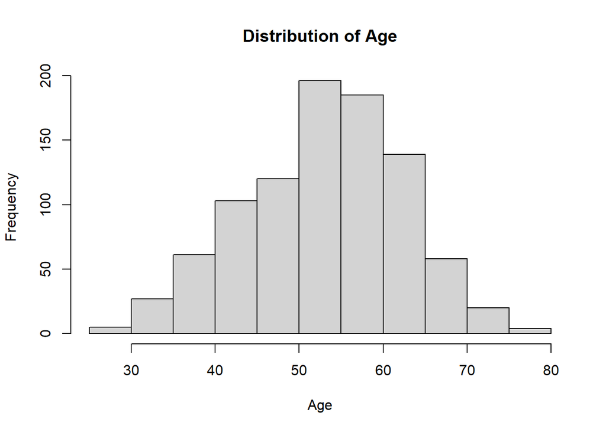

```r
# EDA for Age
hist(dataset$Age, main="Distribution of Age", xlab="Age", ylab="Frequency")
```

**Sex**

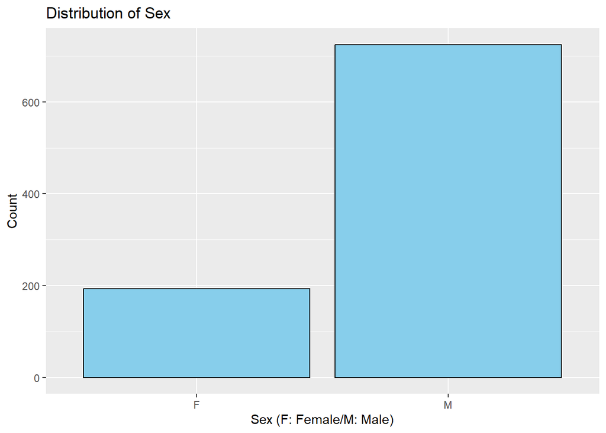

```r
# EDA for Sex
ggplot(dataset, aes(x = Sex)) +
  geom_bar(fill = "skyblue", color = "black") +
  labs(title = "Distribution of Sex", x = "Sex (F: Female/M: Male)", y = "Count")
```

**Resting Blood Pressure**

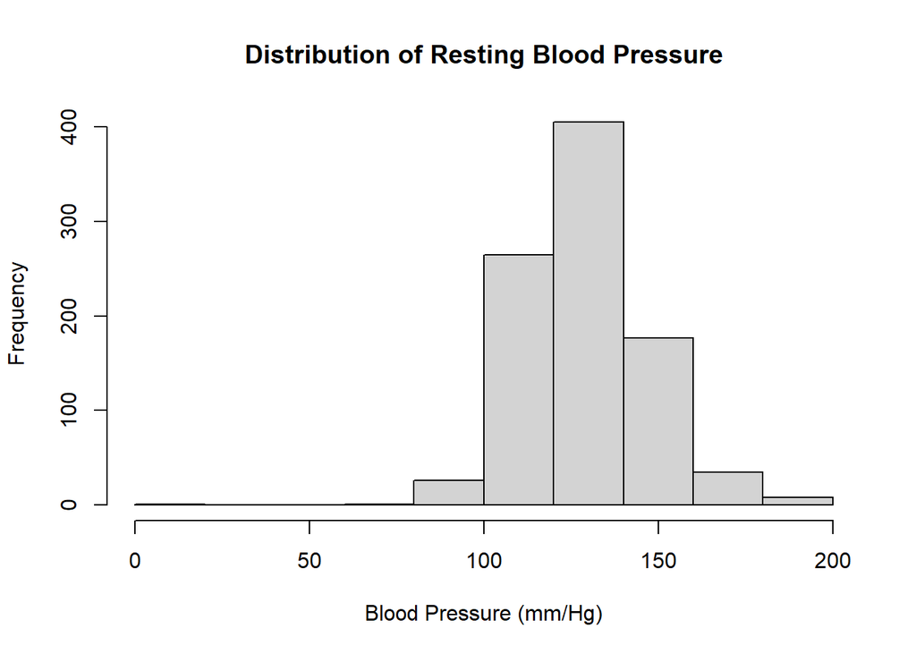

```r
# EDA for Resting Blood Pressure
hist(dataset$RestingBP, main="Distribution of Resting Blood Pressure",
     xlab="Blood Pressure (mm/Hg)", ylab="Frequency")
```

```r
# Check the data points where resting blood pressure is less than 90, since 90 mm/Hg is considered the cutoff point for abnormal blood pressure
any(dataset$RestingBP <= 90)
```

```
## [1] TRUE
```

```r
dataset$RestingBP[which(dataset$RestingBP <= 90)]
```

```
## [1] 80  0
```

**Cholesterol Level**

```r
# EDA for Cholesterol Level
length(dataset$Cholesterol[which(dataset$Cholesterol < 100)])
```

```
## [1] 173
```

```r
dataset$Cholesterol[which(dataset$Cholesterol < 100)]
```

```
##   [1] 85  0  0  0  0  0  0  0  0  0  0  0  0  0  0  0  0  0  0  0  0  0  0  0  0
##  [26]  0  0  0  0  0  0  0  0  0  0  0  0  0  0  0  0  0  0  0  0  0  0  0  0  0
##  [51]  0  0  0  0  0  0  0  0  0  0  0  0  0  0  0  0  0  0  0  0  0  0  0  0  0
##  [76]  0  0  0  0  0  0  0  0  0  0  0  0  0  0  0  0  0  0  0  0  0  0  0  0  0
## [101]  0  0  0  0  0  0  0  0  0  0  0  0  0  0  0  0  0  0  0  0  0  0  0  0  0
## [126]  0  0  0  0  0  0  0  0  0  0  0  0  0  0  0  0  0  0  0  0  0  0  0  0  0
## [151]  0  0  0  0  0  0  0  0  0  0  0  0  0  0  0  0  0  0  0  0  0  0  0
```

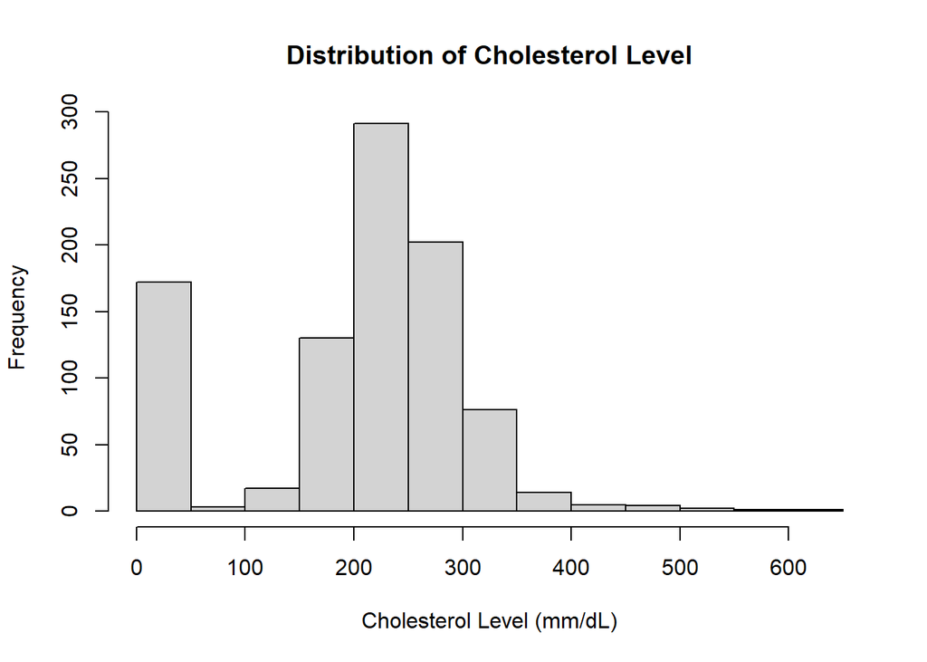

```r
hist(dataset$Cholesterol, main="Distribution of Cholesterol Level",
     xlab="Cholesterol Level (mm/dL)", ylab="Frequency")
```

**Fasting Blood Sugar Level**

```r
# EDA for Fasting Blood Sugar Level
length(which(dataset$FastingBS == 0))
```

```
## [1] 704
```

```r
length(which(dataset$FastingBS == 1))
```

```
## [1] 214
```

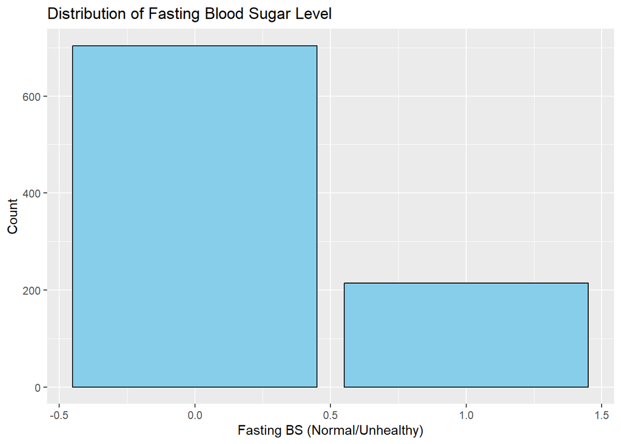

```r
ggplot(dataset, aes(x = FastingBS)) +
  geom_bar(fill = "skyblue", color = "black") +
  labs(title = "Distribution of Fasting Blood Sugar Level",
       x = "Fasting BS (Normal/Unhealthy)", y = "Count")
```

**Heart Disease**

```r
# EDA for Heart Disease
length(which(dataset$HeartDisease == 0))
```

```
## [1] 410
```

```r
length(which(dataset$HeartDisease == 1))
```

```
## [1] 508
```

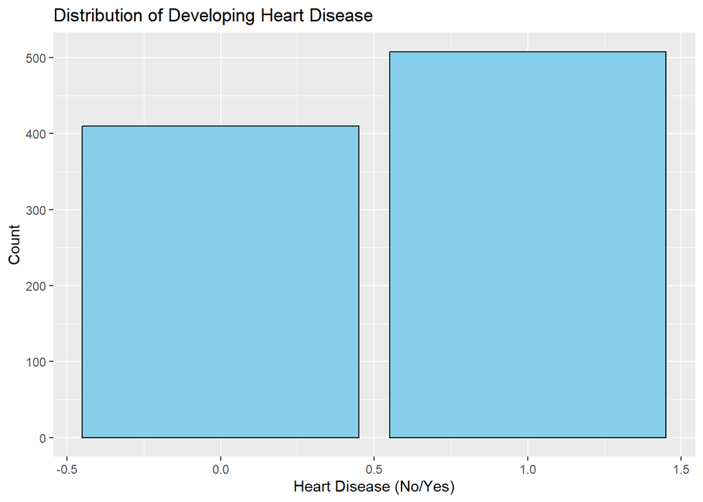

```r
ggplot(dataset, aes(x = HeartDisease)) +
  geom_bar(fill = "skyblue", color = "black") +
  labs(title = "Distribution of Developing Heart Disease",
       x = "Heart Disease (No/Yes)", y = "Count")
```

*Exposures*

Systolic Blood pressure of 80 is abnormally low (hypotension), but it is technically still possible. However, blood pressure of 0 is impossible for living, so I will treat it as a data error.

Cholesterol level of 603mm/dL is possible, though it’s considered very abnormal and pose significant health risk (outlier). There are 172 datapoints where cholesterol level is 0mm/dL. This is not possible for human to live, so I will consider them as invalid data points and remove them.

Individuals with Fasting Blood Sugar level of 120-125 mg/dL is considered to have prediabetes. Individuals with Fasting BS level of 126 mg/dL and up are considered to be diabetic. For my analysis, I will group prediabetes and diabetes together as “Unhealthy”. This dataset transformed this metric into binary categorical variable (0 or 1) using 120 mg/dL as cut-off point (normal vs unhealthy). The fasting blood sugar level between normal and unhealthy group is not balanced: the number of individuals in these groups are 704 and 214 respectively.

*Confounders*

Distribution of age looks normal.

The number of males and females are quite unbalanced: 725 and 193 respectively.

*Outcome*

The numbers of individuals with heart disease or not is quite balanced: 508 and 410 respectively.

## 4.1 Removing invalid datapoints and re-doing data points

```r
library(ggplot2)
# removing invalid data points for Resting Blood Pressure
dataset <- dataset[which(dataset$RestingBP != 0),]

# removing invalid data points for Cholesterol
dataset <- dataset[which(dataset$Cholesterol != 0),]

summary(dataset)
```

```
##       Age        Sex     ChestPainType   RestingBP    Cholesterol
##  Min.   :28.00   F:182   ASY:370       Min.   : 92   Min.   : 85.0
##  1st Qu.:46.00   M:564   ATA:166       1st Qu.:120   1st Qu.:207.2
##  Median :54.00           NAP:169       Median :130   Median :237.0
##  Mean   :52.88           TA : 41       Mean   :133   Mean   :244.6
##  3rd Qu.:59.00                         3rd Qu.:140   3rd Qu.:275.0
##  Max.   :77.00                         Max.   :200   Max.   :603.0
##    FastingBS       RestingECG      MaxHR       ExerciseAngina    Oldpeak
##  Min.   :0.0000   LVH   :176   Min.   : 69.0   N:459          Min.   :-0.1000
##  1st Qu.:0.0000   Normal:445   1st Qu.:122.0   Y:287          1st Qu.: 0.0000
##  Median :0.0000   ST    :125   Median :140.0                  Median : 0.5000
##  Mean   :0.1676                Mean   :140.2                  Mean   : 0.9016
##  3rd Qu.:0.0000                3rd Qu.:160.0                  3rd Qu.: 1.5000
##  Max.   :1.0000                Max.   :202.0                  Max.   : 6.2000
##  ST_Slope    HeartDisease
##  Down: 43   Min.   :0.0000
##  Flat:354   1st Qu.:0.0000
##  Up  :349   Median :0.0000
##             Mean   :0.4772
##             3rd Qu.:1.0000
##             Max.   :1.0000
```

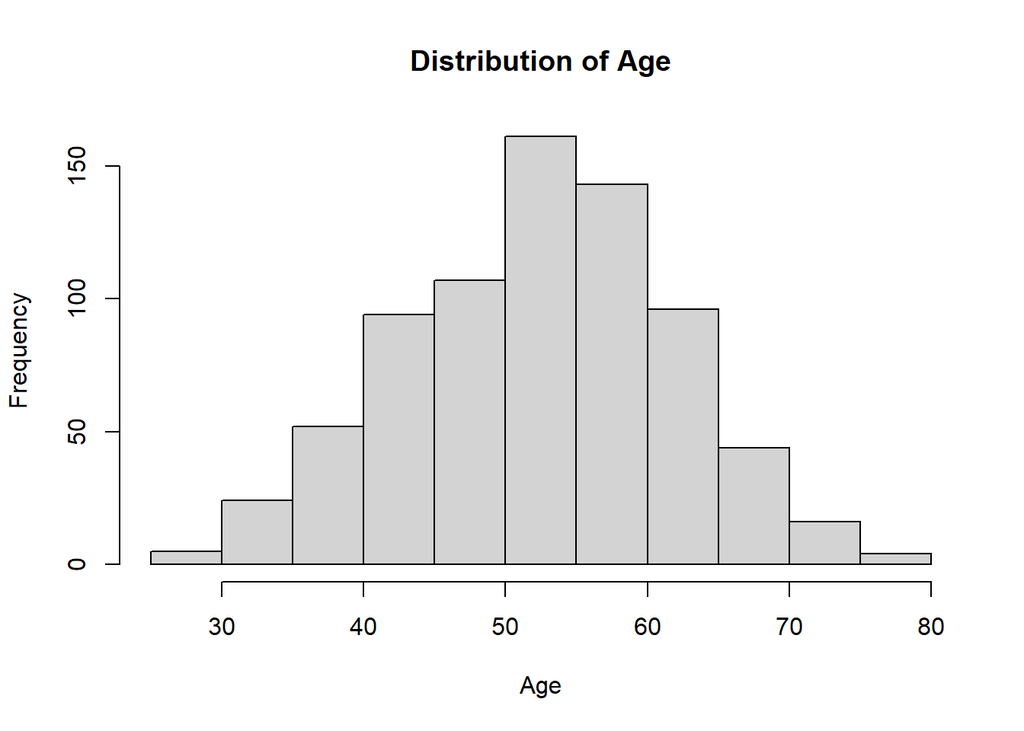

```r
# Univariate Visualization
hist(dataset$Age, main="Distribution of Age", xlab="Age", ylab="Frequency")
```

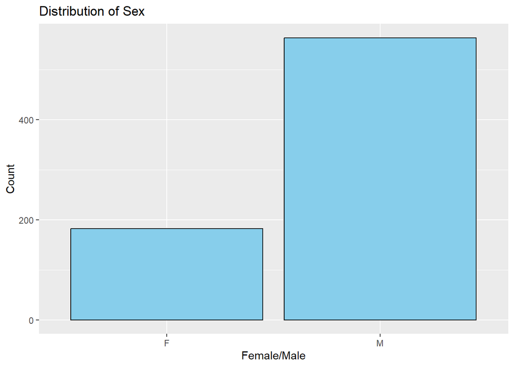

```r
ggplot(dataset, aes(x = Sex)) +
  geom_bar(fill = "skyblue", color = "black") +
  labs(title = "Distribution of Sex", x = "Female/Male", y = "Count")
```

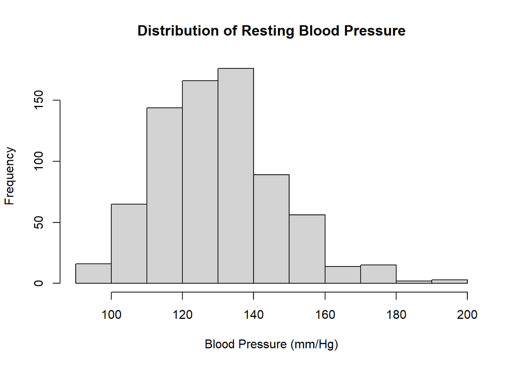

```r
hist(dataset$RestingBP, main="Distribution of Resting Blood Pressure",
     xlab="Blood Pressure (mm/Hg)", ylab="Frequency")
```

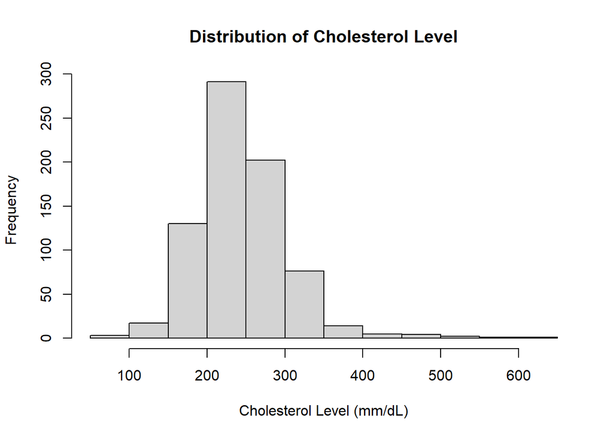

```r
hist(dataset$Cholesterol, main="Distribution of Cholesterol Level",
     xlab="Cholesterol Level (mm/dL)", ylab="Frequency")
```

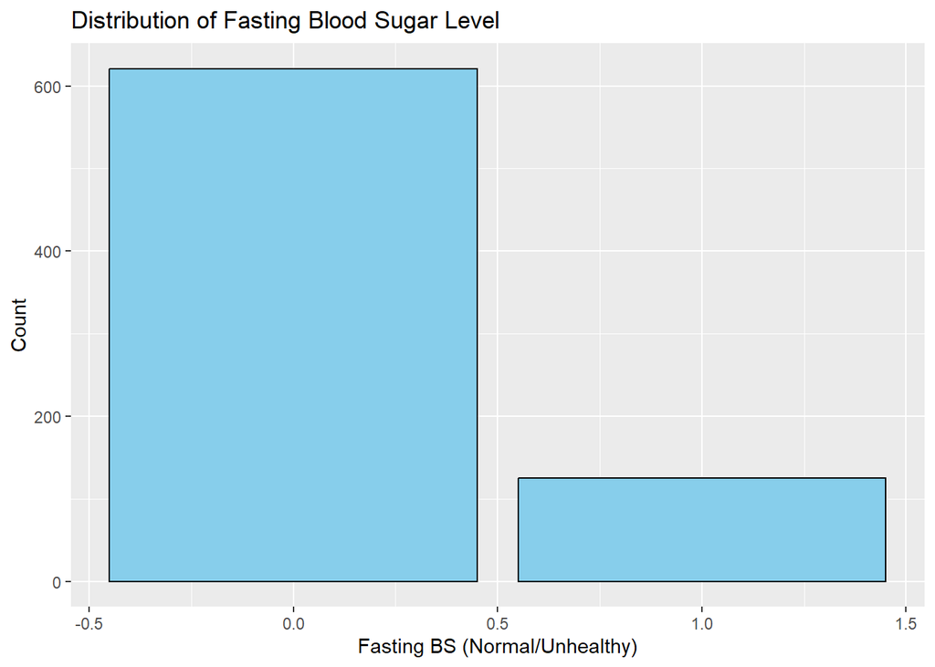

```r
ggplot(dataset, aes(x = FastingBS)) +
  geom_bar(fill = "skyblue", color = "black") +
  labs(title = "Distribution of Fasting Blood Sugar Level",
       x = "Fasting BS (Normal/Unhealthy)", y = "Count")
```

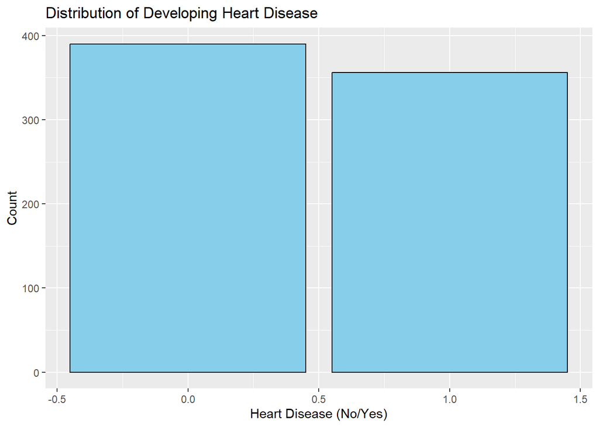

```r
ggplot(dataset, aes(x = HeartDisease)) +
  geom_bar(fill = "skyblue", color = "black") +
  labs(title = "Distribution of Developing Heart Disease",
       x = "Heart Disease (No/Yes)", y = "Count")
```

```r
# Bivariate Visualization

# Create a 2x2 contingency table for Heart Disease vs Fasting Blood Sugar Level
HDvFastingBS <- table(dataset$HeartDisease, dataset$FastingBS)

# Add margins for row and column totals
HDvFastingBS <- addmargins(HDvFastingBS)

# Label rows and columns
rownames(HDvFastingBS) <- c("No HD", "Have HD", "Total")
colnames(HDvFastingBS) <- c("Healthy BS Lvl", "Unhealthy BS Lvl", "Total")
HDvFastingBS
```

```
##
##           Healthy BS Lvl Unhealthy BS Lvl Total
##   No HD              347               43   390
##   Have HD            274               82   356
##   Total              621              125   746
```

```r
# Create a 2x2 contingency table for Heart Disease vs Sex
HDvSex <- table(dataset$HeartDisease, dataset$Sex)

# Add margins for row and column totals
HDvSex <- addmargins(HDvSex)

# Label rows and columns
rownames(HDvSex) <- c("No HD", "Have HD", "Total")
colnames(HDvSex) <- c("Female", "Male", "Total")
HDvSex
```

```
##
##           Female Male Total
##   No HD      142  248   390
##   Have HD     40  316   356
##   Total      182  564   746
```

# 5 GLM Assumptions Verification

Y (outcome) = Healthy or Have Heart Disease

1. Independence of Y
- Each data point represents an individual. Each individual are independent sample, and the likelihood of having heart disease is independent of another individual.
2. Distribution of Y
- Y is a categorical variable with only two levels/ outcomes: Healthy (No Heart Disease) or Have Heart Disease. Thus, I am using binomial logistic regression to model.
3. Correct Link Function
- I will be using logit link as the link function for binomial logistic regression. I want to predict the probability of the outcome. Since probability is limited between 0 and 1, I need to use logit link to transform them to range from $-\infty$ and $\infty$.

# 6 Modelling

## 6.0 Conversion & Factoring

```r
df <- data.frame(dataset)
df$Sex <- factor(df$Sex,
                 levels = c("F", "M"),
                 labels = c("0", "1"))
df$ChestPainType <- factor(df$ChestPainType,
                           levels = c("ASY", "NAP", "ATA", "TA"),
                           labels = c("0", "1", "2", "3"))
df$FastingBS <- factor(df$FastingBS)
df$RestingECG <- factor(df$RestingECG,
                        levels = c("Normal", "ST", "LVH"),
                        labels = c("0", "1", "1"))
df$ExerciseAngina <- factor(df$ExerciseAngina,
                            levels = c("N", "Y"),
                            labels = c("0", 1))
df$ST_Slope <- factor(df$ST_Slope,
                      levels = c("Up", "Flat", "Down"),
                      labels = c("0", "1", "1"))
df$HeartDisease <- factor(df$HeartDisease)
summary(df)
```

```
##       Age        Sex     ChestPainType   RestingBP    Cholesterol    FastingBS
##  Min.   :28.00   0:182   0:370         Min.   : 92   Min.   : 85.0   0:621
##  1st Qu.:46.00   1:564   1:169         1st Qu.:120   1st Qu.:207.2   1:125
##  Median :54.00           2:166         Median :130   Median :237.0
##  Mean   :52.88           3: 41         Mean   :133   Mean   :244.6
##  3rd Qu.:59.00                         3rd Qu.:140   3rd Qu.:275.0
##  Max.   :77.00                         Max.   :200   Max.   :603.0
##  RestingECG     MaxHR       ExerciseAngina    Oldpeak        ST_Slope
##  0:445      Min.   : 69.0   0:459          Min.   :-0.1000   0:349
##  1:301      1st Qu.:122.0   1:287          1st Qu.: 0.0000   1:397
##             Median :140.0                  Median : 0.5000
##             Mean   :140.2                  Mean   : 0.9016
##             3rd Qu.:160.0                  3rd Qu.: 1.5000
##             Max.   :202.0                  Max.   : 6.2000
##  HeartDisease
##  0:390
##  1:356
##
##
##
##
```

## 6.1 Logistic model

```r
logit.mod.all <- glm(HeartDisease ~ Age + Sex + ChestPainType + RestingBP + Cholesterol + FastingBS + RestingECG + MaxHR + ExerciseAngina + Oldpeak + ST_Slope,
                  family = binomial(link=logit),
                  data = df)
summary(logit.mod.all)
```

```
##
## Call:
## glm(formula = HeartDisease ~ Age + Sex + ChestPainType + RestingBP +
##     Cholesterol + FastingBS + RestingECG + MaxHR + ExerciseAngina +
##     Oldpeak + ST_Slope, family = binomial(link = logit), data = df)
##
## Coefficients:
##                   Estimate Std. Error z value Pr(>|z|)
## (Intercept)     -6.8627033  1.6600216  -4.134 3.56e-05 ***
## Age              0.0317474  0.0146134   2.172 0.029820 *
## Sex1             1.8149212  0.3087587   5.878 4.15e-09 ***
## ChestPainType1  -1.5714573  0.2990705  -5.254 1.48e-07 ***
## ChestPainType2  -1.6804188  0.3485760  -4.821 1.43e-06 ***
## ChestPainType3  -1.6559439  0.4806150  -3.445 0.000570 ***
## RestingBP        0.0116367  0.0072656   1.602 0.109240
## Cholesterol      0.0027638  0.0019765   1.398 0.162019
## FastingBS1       0.2220341  0.3256609   0.682 0.495368
## RestingECG1      0.1383580  0.2444977   0.566 0.571471
## MaxHR            0.0007221  0.0055807   0.129 0.897043
## ExerciseAngina1  0.9479659  0.2630348   3.604 0.000313 ***
## Oldpeak          0.3140886  0.1342258   2.340 0.019284 *
## ST_Slope1        2.4486325  0.2773632   8.828  < 2e-16 ***
## ---
## Signif. codes:  0 '***' 0.001 '**' 0.01 '*' 0.05 '.' 0.1 ' ' 1
##
## (Dispersion parameter for binomial family taken to be 1)
##
##     Null deviance: 1032.63  on 745  degrees of freedom
## Residual deviance:  489.75  on 732  degrees of freedom
## AIC: 517.75
##
## Number of Fisher Scoring iterations: 6
```

## 6.2 Checking multicollinearity

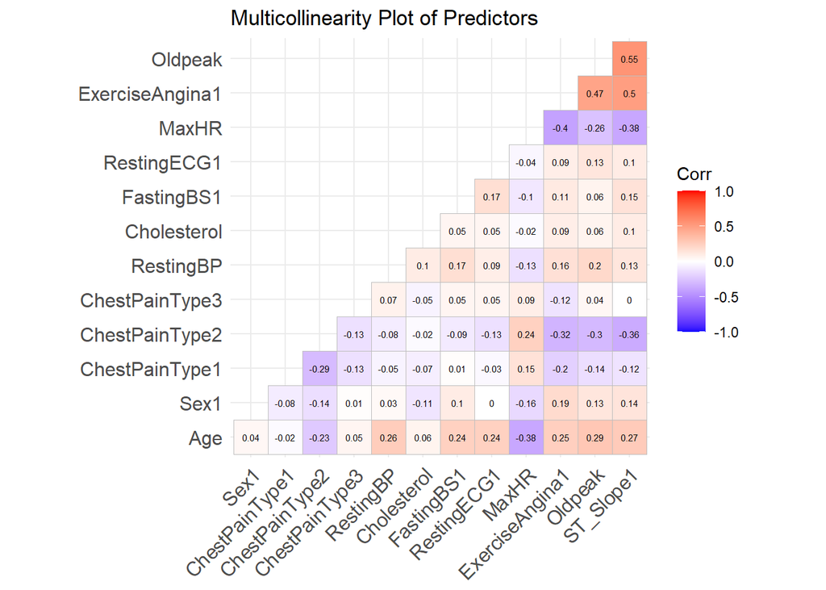

```r
library(ggplot2)
library(ggcorrplot)
library(magrittr)

fmla = formula(HeartDisease~.-HeartDisease)
x <- model.matrix(fmla, data=df)

x %>%
  cor(use="pairwise.complete.obs") %>%
  ggcorrplot(show.diag=FALSE, type="lower", lab=TRUE, lab_size=2,
             title = "Multicollinearity Plot of Predictors")
```

# 7 Model Selection

Stepwise selection based on AIC and BIC

## 7.1 AIC Model

First let’s perform AIC based stepwise selection

```r
## Stepwise elimination based on AIC ##
sel.var.aic <- step(logit.mod.all, trace = 0, k = 2, direction = "both")
select_var_aic<-attr(terms(sel.var.aic), "term.labels")
select_var_aic
```

```
## [1] "Age"            "Sex"            "ChestPainType"  "RestingBP"
## [5] "Cholesterol"    "ExerciseAngina" "Oldpeak"        "ST_Slope"
```

```r
logit.mod.aic <- glm(HeartDisease ~.,
                     family = binomial(link=logit),
                     data = df[, which(colnames(df) %in%
                                              c(select_var_aic, "HeartDisease"))])
summary(logit.mod.aic)
```

```
##
## Call:
## glm(formula = HeartDisease ~ ., family = binomial(link = logit),
##     data = df[, which(colnames(df) %in% c(select_var_aic, "HeartDisease"))])
##
## Coefficients:
##                  Estimate Std. Error z value Pr(>|z|)
## (Intercept)     -6.974479   1.238674  -5.631 1.80e-08 ***
## Age              0.034483   0.013279   2.597 0.009406 **
## Sex1             1.847433   0.305545   6.046 1.48e-09 ***
## ChestPainType1  -1.554422   0.293138  -5.303 1.14e-07 ***
## ChestPainType2  -1.689355   0.344385  -4.905 9.32e-07 ***
## ChestPainType3  -1.620054   0.469716  -3.449 0.000563 ***
## RestingBP        0.012360   0.007179   1.722 0.085118 .
## Cholesterol      0.002905   0.001973   1.472 0.140933
## ExerciseAngina1  0.938842   0.258965   3.625 0.000289 ***
## Oldpeak          0.313092   0.133614   2.343 0.019116 *
## ST_Slope1        2.458472   0.268866   9.144  < 2e-16 ***
## ---
## Signif. codes:  0 '***' 0.001 '**' 0.01 '*' 0.05 '.' 0.1 ' ' 1
##
## (Dispersion parameter for binomial family taken to be 1)
##
##     Null deviance: 1032.63  on 745  degrees of freedom
## Residual deviance:  490.64  on 735  degrees of freedom
## AIC: 512.64
##
## Number of Fisher Scoring iterations: 6
```

## 7.2 BIC Model

Now perform BIC based selection,

```r
## Stepwise elimination based on BIC ##
sel.var.bic <- step(logit.mod.all, trace = 0, k = log(nrow(df)), direction = "both")
select_var_bic<-attr(terms(sel.var.bic), "term.labels")
select_var_bic
```

```
## [1] "Age"            "Sex"            "ChestPainType"  "ExerciseAngina"
## [5] "ST_Slope"
```

```r
logit.mod.bic <- glm(HeartDisease ~.,
                     family = binomial(link=logit),
                     data = df[, which(colnames(df) %in%
                                              c(select_var_bic, "HeartDisease"))])
summary(logit.mod.bic)
```

```
##
## Call:
## glm(formula = HeartDisease ~ ., family = binomial(link = logit),
##     data = df[, which(colnames(df) %in% c(select_var_bic, "HeartDisease"))])
##
## Coefficients:
##                 Estimate Std. Error z value Pr(>|z|)
## (Intercept)     -4.88432    0.78055  -6.258 3.91e-10 ***
## Age              0.04272    0.01287   3.319 0.000904 ***
## Sex1             1.73331    0.29215   5.933 2.98e-09 ***
## ChestPainType1  -1.60073    0.29049  -5.510 3.58e-08 ***
## ChestPainType2  -1.72165    0.33792  -5.095 3.49e-07 ***
## ChestPainType3  -1.47790    0.45847  -3.224 0.001266 **
## ExerciseAngina1  1.09859    0.25114   4.374 1.22e-05 ***
## ST_Slope1        2.69991    0.25032  10.786  < 2e-16 ***
## ---
## Signif. codes:  0 '***' 0.001 '**' 0.01 '*' 0.05 '.' 0.1 ' ' 1
##
## (Dispersion parameter for binomial family taken to be 1)
##
##     Null deviance: 1032.63  on 745  degrees of freedom
## Residual deviance:  502.82  on 738  degrees of freedom
## AIC: 518.82
##
## Number of Fisher Scoring iterations: 5
```

## 7.3 Elastic Net Model

```r
library(glmnet)
```

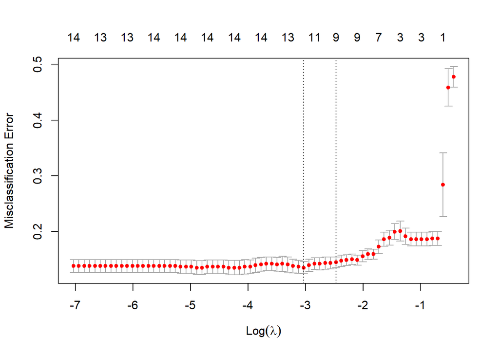

```r
fmla = formula(HeartDisease~.-HeartDisease-1)
x <- model.matrix(fmla, data=df)

y <- df$HeartDisease

cv.en = cv.glmnet(x, y, family = "binomial", type.measure = "class", alpha = 0.5)

plot(cv.en)
```

```r
best.lambda.en <- cv.en$lambda.1se
best.lambda.en
```

```
## [1] 0.08434845
```

```r
co.en <- coef(cv.en, s = "lambda.1se")
co.en
```

```
## 15 x 1 sparse Matrix of class "dgCMatrix"
##                           s1
## (Intercept)     -1.384868341
## Age              0.007584819
## Sex0            -0.312810671
## Sex1             0.310474906
## ChestPainType1  -0.326748804
## ChestPainType2  -0.479953510
## ChestPainType3   .
## RestingBP        .
## Cholesterol      .
## FastingBS1       .
## RestingECG1      .
## MaxHR           -0.002940803
## ExerciseAngina1  0.828498291
## Oldpeak          0.215592948
## ST_Slope1        1.453728890
```

```r
thresh <- 0.0
# sel variables
inds <- which(abs(co.en) > thresh)
variables <- row.names(co.en)[inds]
sel.var.en <- variables[!(variables %in% '(Intercept)')]

print("Selected Variables:")
```

```
## [1] "Selected Variables:"
```

```r
sel.var.en
```

```
## [1] "Age"             "Sex0"            "Sex1"            "ChestPainType1"
## [5] "ChestPainType2"  "MaxHR"           "ExerciseAngina1" "Oldpeak"
## [9] "ST_Slope1"
```

```r
logit.mod.en <- glm(HeartDisease ~.,
                     family = binomial(link=logit),
                     data = df[, which(colnames(df) %in%
                                              c(sel.var.en, "HeartDisease"))])
summary(logit.mod.en)
```

```
##
## Call:
## glm(formula = HeartDisease ~ ., family = binomial(link = logit),
##     data = df[, which(colnames(df) %in% c(sel.var.en, "HeartDisease"))])
##
## Coefficients:
##              Estimate Std. Error z value Pr(>|z|)
## (Intercept)  1.066937   0.896880   1.190  0.23420
## Age          0.027482   0.010520   2.612  0.00899 **
## MaxHR       -0.025408   0.004093  -6.207  5.4e-10 ***
## Oldpeak      1.105930   0.107496  10.288  < 2e-16 ***
## ---
## Signif. codes:  0 '***' 0.001 '**' 0.01 '*' 0.05 '.' 0.1 ' ' 1
##
## (Dispersion parameter for binomial family taken to be 1)
##
##     Null deviance: 1032.63  on 745  degrees of freedom
## Residual deviance:  753.01  on 742  degrees of freedom
## AIC: 761.01
##
## Number of Fisher Scoring iterations: 4
```

## 7.4 Lasso Model

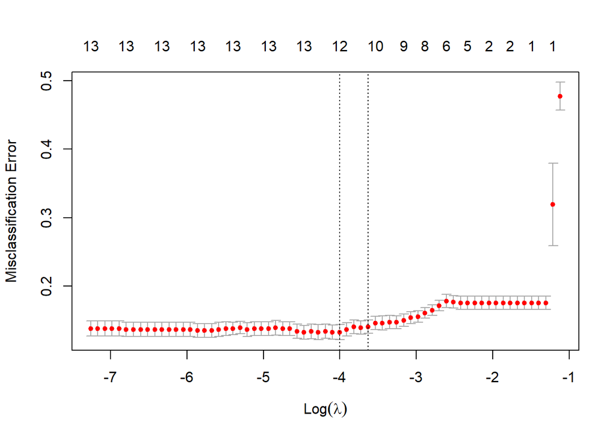

```r
cv.lasso = cv.glmnet(x, y, family = "binomial", type.measure = "class", alpha = 1)

plot(cv.lasso)
```

```r
best.lambda.lasso <- cv.lasso$lambda.1se
best.lambda.lasso
```

```
## [1] 0.02648664
```

```r
co.lasso <- coef(cv.lasso, s = "lambda.1se")
co.lasso
```

```
## 15 x 1 sparse Matrix of class "dgCMatrix"
##                            s1
## (Intercept)     -2.020481e+00
## Age              1.558338e-02
## Sex0            -9.814591e-01
## Sex1             2.208861e-13
## ChestPainType1  -7.145376e-01
## ChestPainType2  -8.236412e-01
## ChestPainType3  -2.221710e-01
## RestingBP        1.914511e-04
## Cholesterol      .
## FastingBS1       .
## RestingECG1      .
## MaxHR           -3.106459e-04
## ExerciseAngina1  9.915169e-01
## Oldpeak          2.043784e-01
## ST_Slope1        2.004334e+00
```

```r
thresh <- 0.0
# sel variables
inds <- which(abs(co.lasso) > thresh)
variables <- row.names(co.lasso)[inds]
sel.var.lasso <- variables[!(variables %in% '(Intercept)')]

print("Selected Variables:")
```

```
## [1] "Selected Variables:"
```

```r
sel.var.lasso
```

```
##  [1] "Age"             "Sex0"            "Sex1"            "ChestPainType1"
##  [5] "ChestPainType2"  "ChestPainType3"  "RestingBP"       "MaxHR"
##  [9] "ExerciseAngina1" "Oldpeak"         "ST_Slope1"
```

```r
logit.mod.lasso <- glm(HeartDisease ~.,
                     family = binomial(link=logit),
                     data = df[, which(colnames(df) %in%
                                              c(sel.var.lasso, "HeartDisease"))])
summary(logit.mod.lasso)
```

```
##
## Call:
## glm(formula = HeartDisease ~ ., family = binomial(link = logit),
##     data = df[, which(colnames(df) %in% c(sel.var.lasso, "HeartDisease"))])
##
## Coefficients:
##              Estimate Std. Error z value Pr(>|z|)
## (Intercept)  0.194972   1.067961   0.183   0.8551
## Age          0.023897   0.010772   2.219   0.0265 *
## RestingBP    0.008184   0.005475   1.495   0.1350
## MaxHR       -0.025517   0.004097  -6.228 4.73e-10 ***
## Oldpeak      1.096981   0.107819  10.174  < 2e-16 ***
## ---
## Signif. codes:  0 '***' 0.001 '**' 0.01 '*' 0.05 '.' 0.1 ' ' 1
##
## (Dispersion parameter for binomial family taken to be 1)
##
##     Null deviance: 1032.63  on 745  degrees of freedom
## Residual deviance:  750.76  on 741  degrees of freedom
## AIC: 760.76
##
## Number of Fisher Scoring iterations: 4
```

# 8 Model Diagnostics and Validation

#### VIF for all models

```r
library(car)
vif(logit.mod.all)
```

```
##                    GVIF Df GVIF^(1/(2*Df))
## Age            1.317973  1        1.148030
## Sex            1.148956  1        1.071894
## ChestPainType  1.271593  3        1.040858
## RestingBP      1.105185  1        1.051278
## Cholesterol    1.057015  1        1.028113
## FastingBS      1.093176  1        1.045551
## RestingECG     1.090345  1        1.044196
## MaxHR          1.313170  1        1.145936
## ExerciseAngina 1.189983  1        1.090864
## Oldpeak        1.257746  1        1.121493
## ST_Slope       1.368322  1        1.169753
```

```r
vif(logit.mod.aic)
```

```
##                    GVIF Df GVIF^(1/(2*Df))
## Age            1.088045  1        1.043094
## Sex            1.126411  1        1.061325
## ChestPainType  1.193438  3        1.029912
## RestingBP      1.087718  1        1.042937
## Cholesterol    1.048928  1        1.024172
## ExerciseAngina 1.156063  1        1.075204
## Oldpeak        1.250063  1        1.118062
## ST_Slope       1.290504  1        1.136003
```

```r
vif(logit.mod.bic)
```

```
##                    GVIF Df GVIF^(1/(2*Df))
## Age            1.027814  1        1.013812
## Sex            1.093451  1        1.045682
## ChestPainType  1.161739  3        1.025301
## ExerciseAngina 1.117889  1        1.057303
## ST_Slope       1.145505  1        1.070282
```

```r
vif(logit.mod.en)
```

```
##      Age    MaxHR  Oldpeak
## 1.082618 1.069931 1.013319
```

```r
vif(logit.mod.lasso)
```

```
##       Age RestingBP     MaxHR   Oldpeak
##  1.137249  1.053815  1.071411  1.014265
```

## 8.1 Diagnostics for stepwise-AIC model

#### DFBetas

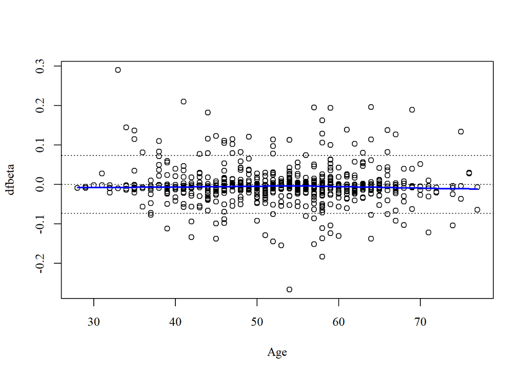

```r
# Calculating DFBetas for AIC model
dfbetas.aic <- dfbetas(logit.mod.aic)
par(family = 'serif')

# Age
plot(df$Age, dfbetas.aic[,1], xlab='Age',
     ylab='dfbeta')
lines(lowess(df$Age, dfbetas.aic[,1]), lwd=2, col='blue')
abline(h=0, lty='dotted')
abline(h=-2/sqrt(nrow(dfbetas.aic)), lty='dotted')
abline(h=2/sqrt(nrow(dfbetas.aic)), lty='dotted')
```

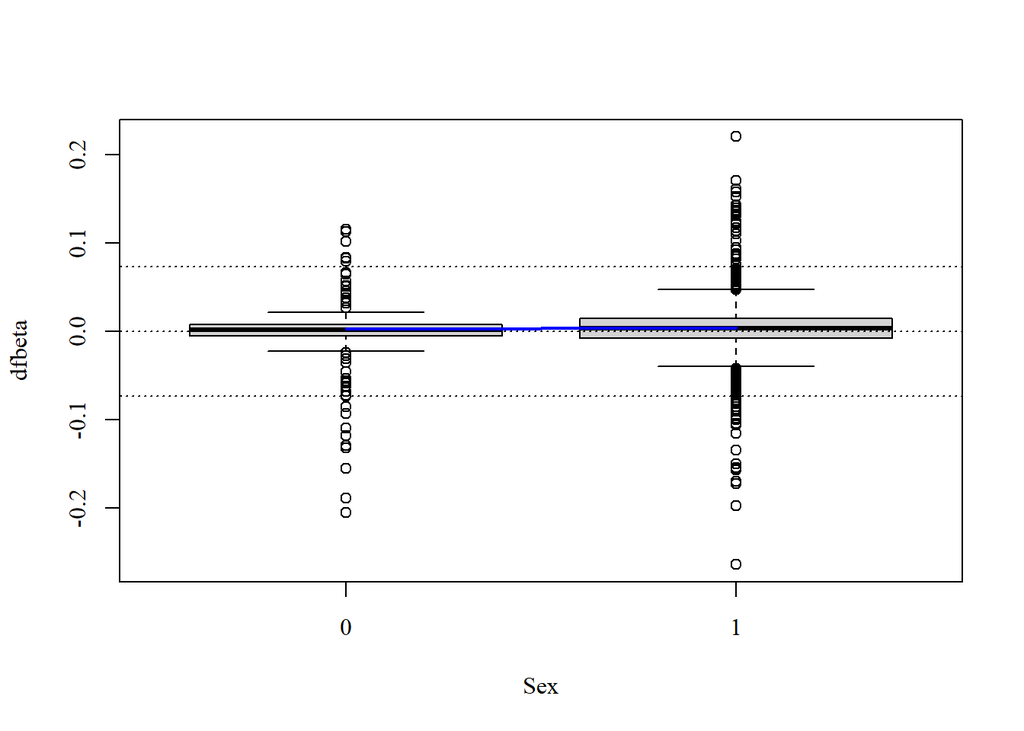

```r
# Sex
plot(df$Sex, dfbetas.aic[,2], xlab='Sex',
     ylab='dfbeta')
lines(lowess(df$Sex, dfbetas.aic[,2]), lwd=2, col='blue')
abline(h=0, lty='dotted')
abline(h=-2/sqrt(nrow(dfbetas.aic)), lty='dotted')
abline(h=2/sqrt(nrow(dfbetas.aic)), lty='dotted')
```

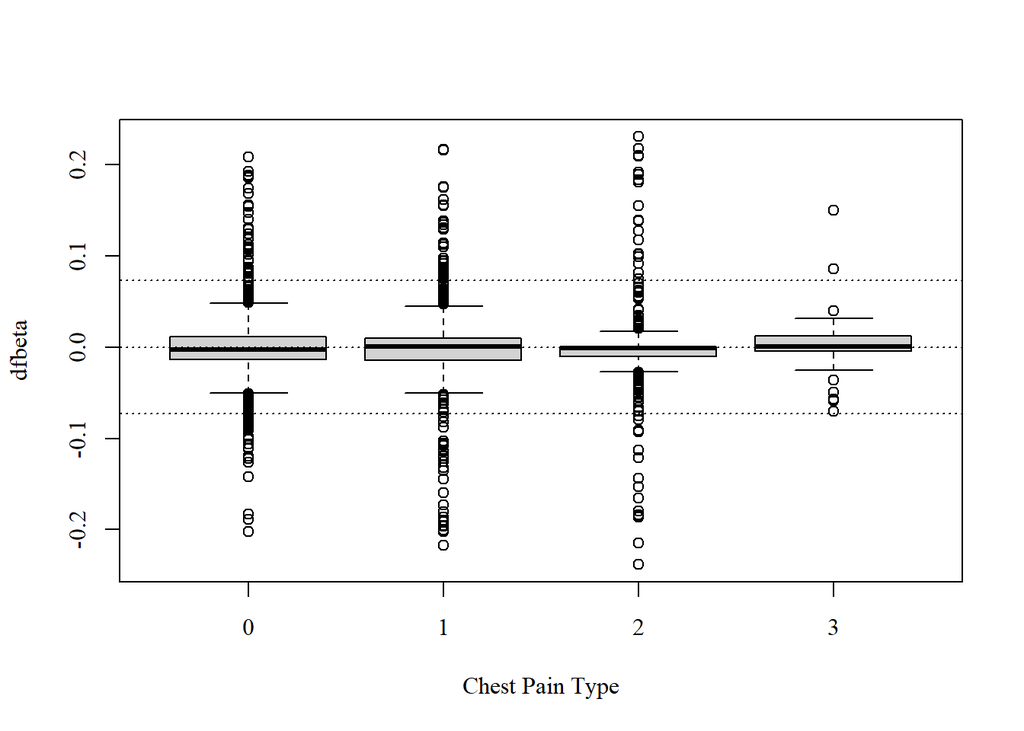

```r
# Chest Pain Types
plot(df$ChestPainType, dfbetas.aic[,3:5], xlab='Chest Pain Type',
     ylab='dfbeta')
#lines(lowess(df$ChestPainType, dfbetas.aic[,3:5]), lwd=2, col='blue')
abline(h=0, lty='dotted')
abline(h=-2/sqrt(nrow(dfbetas.aic)), lty='dotted')
abline(h=2/sqrt(nrow(dfbetas.aic)), lty='dotted')
```

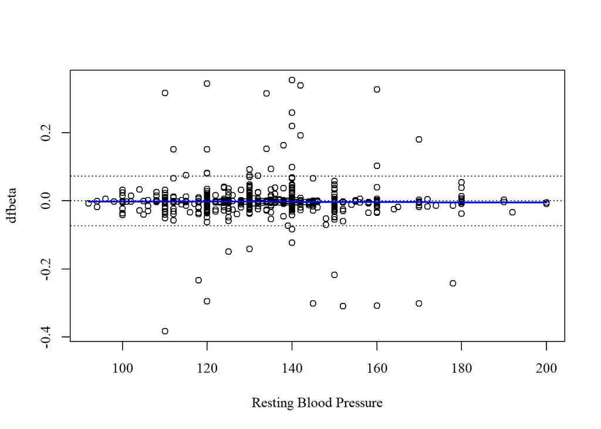

```r
# Resting Blood Pressure
plot(df$RestingBP, dfbetas.aic[,6], xlab='Resting Blood Pressure',
     ylab='dfbeta')
lines(lowess(df$RestingBP, dfbetas.aic[,6]), lwd=2, col='blue')
abline(h=0, lty='dotted')
abline(h=-2/sqrt(nrow(dfbetas.aic)), lty='dotted')
abline(h=2/sqrt(nrow(dfbetas.aic)), lty='dotted')
```

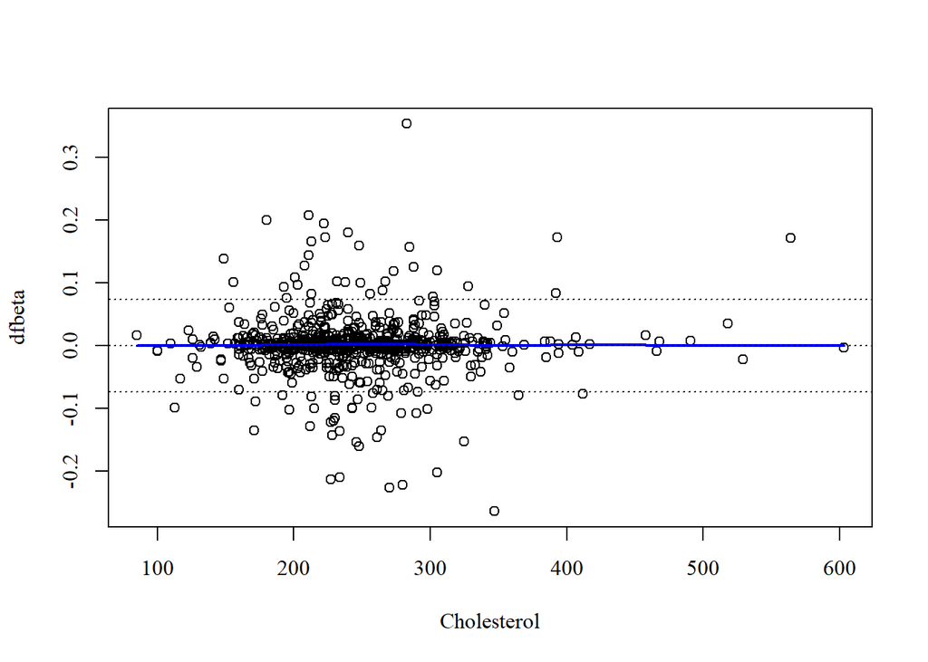

```r
# Cholesterol
plot(df$Cholesterol, dfbetas.aic[,7], xlab='Cholesterol',
     ylab='dfbeta')
lines(lowess(df$Cholesterol, dfbetas.aic[,7]), lwd=2, col='blue')
abline(h=0, lty='dotted')
abline(h=-2/sqrt(nrow(dfbetas.aic)), lty='dotted')
abline(h=2/sqrt(nrow(dfbetas.aic)), lty='dotted')
```

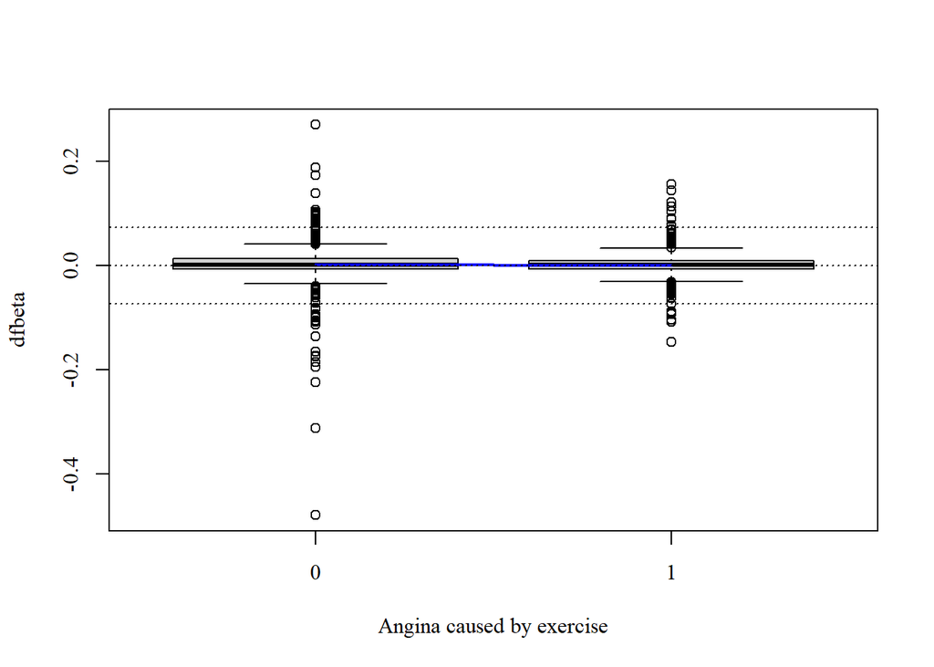

```r
# Angina caused by exercise
plot(df$ExerciseAngina, dfbetas.aic[,8], xlab='Angina caused by exercise',
     ylab='dfbeta')
lines(lowess(df$ExerciseAngina, dfbetas.aic[,8]), lwd=2, col='blue')
abline(h=0, lty='dotted')
abline(h=-2/sqrt(nrow(dfbetas.aic)), lty='dotted')
abline(h=2/sqrt(nrow(dfbetas.aic)), lty='dotted')
```

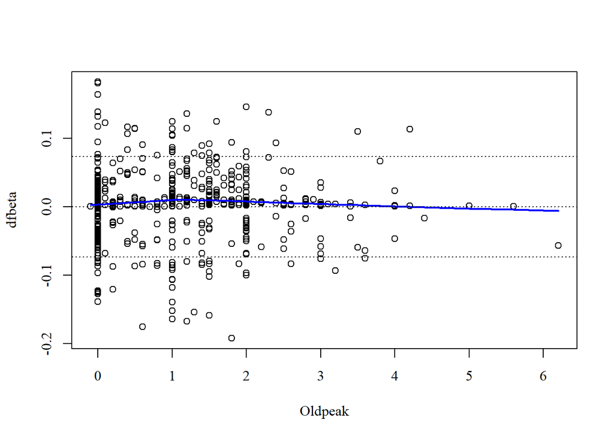

```r
# Oldpeak
plot(df$Oldpeak, dfbetas.aic[,9], xlab='Oldpeak',
     ylab='dfbeta')
lines(lowess(df$Oldpeak, dfbetas.aic[,9]), lwd=2, col='blue')
abline(h=0, lty='dotted')
abline(h=-2/sqrt(nrow(dfbetas.aic)), lty='dotted')
abline(h=2/sqrt(nrow(dfbetas.aic)), lty='dotted')
```

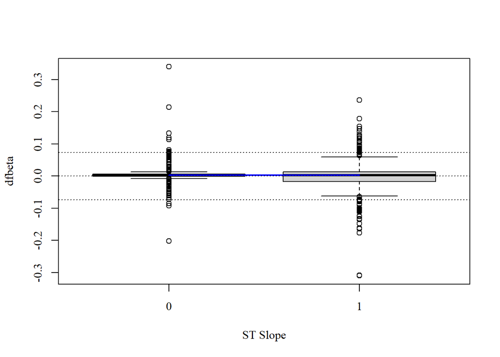

```r
# ST Slope
plot(df$ST_Slope, dfbetas.aic[,10], xlab='ST Slope',
     ylab='dfbeta')
lines(lowess(df$ST_Slope, dfbetas.aic[,10]), lwd=2, col='blue')
abline(h=0, lty='dotted')
abline(h=-2/sqrt(nrow(dfbetas.aic)), lty='dotted')
abline(h=2/sqrt(nrow(dfbetas.aic)), lty='dotted')
```

#### DFFits

```r
# Calculating DFFits for AIC model
dffits.aic <- dffits(logit.mod.aic)
influential_pts <- abs(dffits.aic) > 2*sqrt((length(logit.mod.aic$coefficients)-1)/nrow(df))
length(which(influential_pts))
```

```
## [1] 113
```

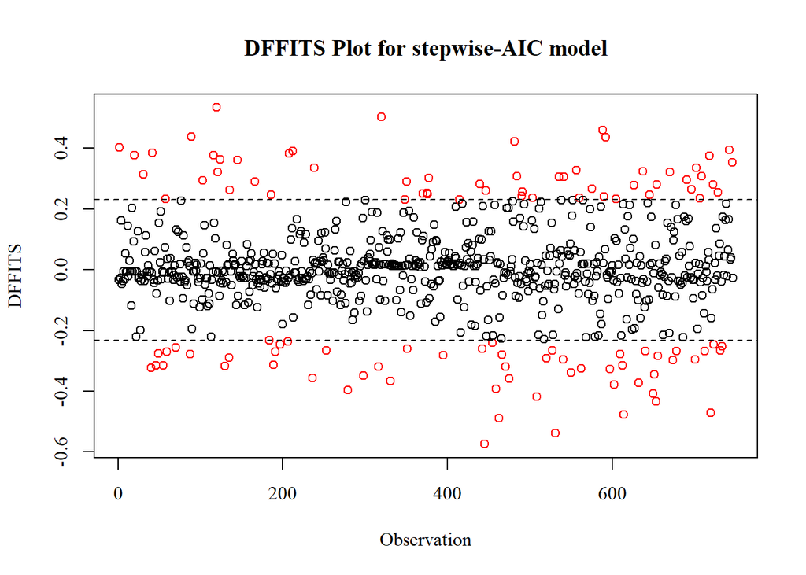

```r
par(family = 'serif')

plot(dffits.aic, main="DFFITS Plot for stepwise-AIC model", xlab="Observation",
     ylab="DFFITS", col = ifelse(influential_pts, "red", "black"))
#Critical Value horizontal lines
abline(h = 2*sqrt((length(logit.mod.aic$coefficients)-1)/nrow(df)), lty = 2)
abline(h = -2*sqrt((length(logit.mod.aic$coefficients)-1)/nrow(df)), lty = 2)
```

#### Cook’s Distance

```r
cd.aic <-cooks.distance(logit.mod.aic)
length(which(cd.aic > qf(0.5, 12+1, 746-12-1)))  #qf(0.5, p+1, n-p-1), where n =746, p=12
```

```
## [1] 0
```

```r
influential_pts <- cd.aic > 4/length(cd.aic)
length(which(influential_pts)) # number of influential points
```

```
## [1] 72
```

```r
length(which(influential_pts))/length(cd.aic)*100 # proportion of data points that are influential
```

```
## [1] 9.651475
```

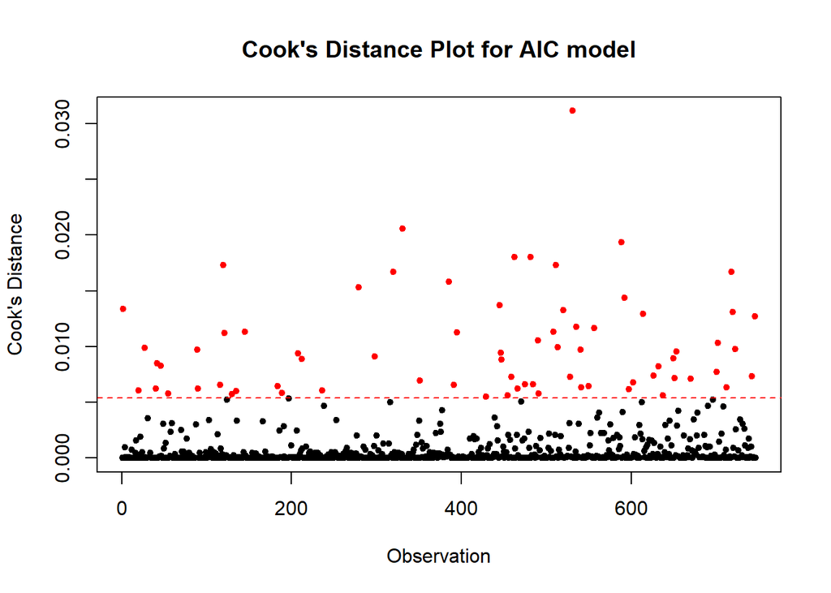

```r
# Plot Cook's distance
plot(cd.aic, pch = 20, col = ifelse(influential_pts, "red", "black"),
     main = "Cook's Distance Plot for AIC model", xlab = "Observation", ylab = "Cook's Distance")

# Adding a horizontal line at Cook's distance cutoff (4/n)
abline(h = 4/length(cd.aic), col = "red", lty = 2)
```

#### Cross Validation & Calibration plot

```r
library(rms)
```

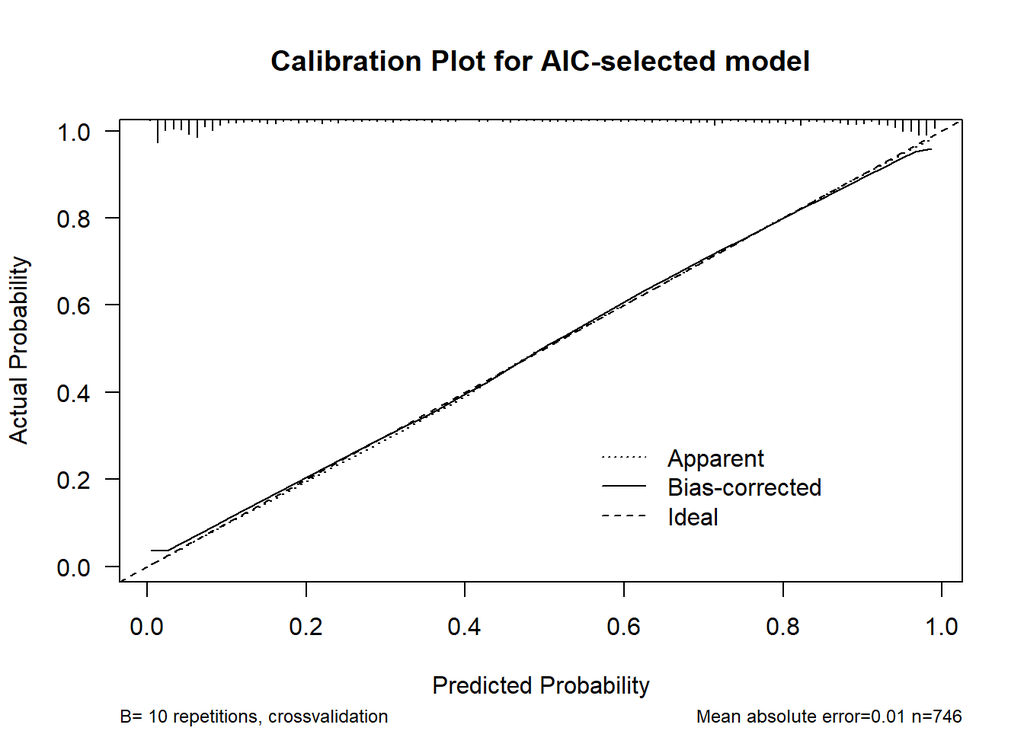

```
##
## n=746   Mean absolute error=0.01   Mean squared error=0.00017
## 0.9 Quantile of absolute error=0.022
```

```r
## Fit the model with lrm from rms package ##
lrm.aic <- lrm(HeartDisease ~ ., data = df[,which(colnames(df) %in% c(select_var_aic, "HeartDisease"))], x =TRUE, y = TRUE, model= T)

 # model calibration
cross.calib.aic <- calibrate(lrm.aic, method="crossvalidation", B=10)
plot(cross.calib.aic, las=1, xlab = "Predicted Probability",
     main = "Calibration Plot for AIC-selected model")
```

#### ROC Curve

```r
library(pROC)
p.aic <- predict(lrm.aic, type = "fitted")

roc.aic <- roc(df$HeartDisease ~ p.aic)
```

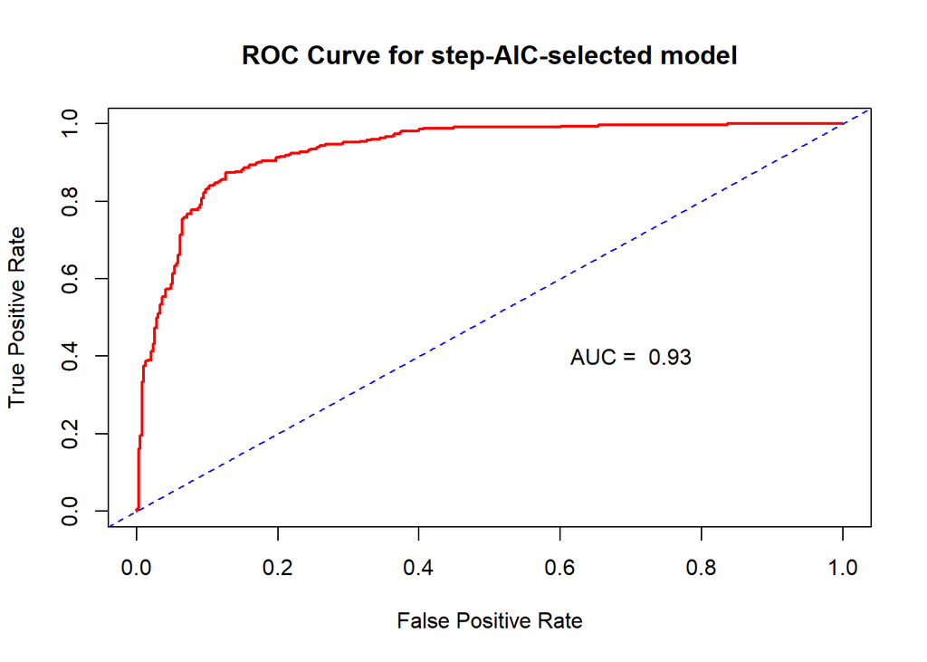

```r
## The True Positive Rate ##
TPR.aic <- roc.aic$sensitivities
## The False Positive Rate ##
FPR.aic <- 1 - roc.aic$specificities

plot(FPR.aic, TPR.aic, xlim = c(0,1), ylim = c(0,1), type = 'l', lty = 1, lwd = 2,col = 'red', xlab = "False Positive Rate", ylab = "True Positive Rate",
     main = "ROC Curve for step-AIC-selected model")
abline(a = 0, b = 1, lty = 2, col = 'blue')
text(0.7,0.4,label = paste("AUC = ", round(auc(roc.aic),2)))
```

```r
auc(roc.aic)
```

```
## Area under the curve: 0.9338
```

## 8.2 Diagnostics for stepwise-BIC model

#### DFFits

```r
# Calculating DFFits for bic model
dffits.bic <- dffits(logit.mod.bic)
influential_pts <- abs(dffits.bic) > 2*sqrt((length(logit.mod.bic$coefficients)-1)/nrow(df))
length(which(influential_pts))
```

```
## [1] 123
```

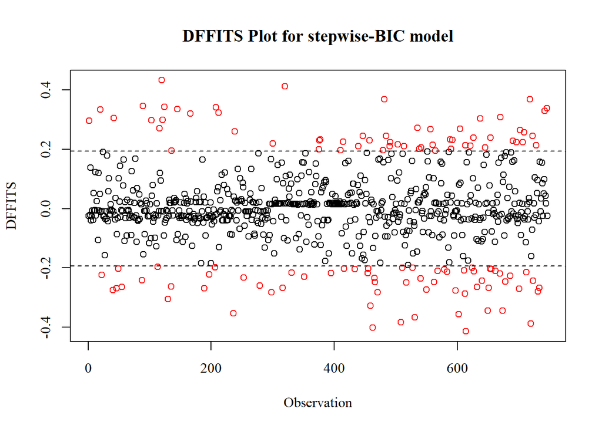

```r
par(family = 'serif')

plot(dffits.bic, main="DFFITS Plot for stepwise-BIC model", xlab="Observation", ylab="DFFITS", col = ifelse(influential_pts, "red", "black"))
#Critical Value horizontal lines
abline(h = 2*sqrt((length(logit.mod.bic$coefficients)-1)/nrow(df)), lty = 2)
abline(h = -2*sqrt((length(logit.mod.bic$coefficients)-1)/nrow(df)), lty = 2)
```

#### Cook’s Distance

```r
cd.bic <-cooks.distance(logit.mod.bic)
influential_pts <- cd.bic > 4/length(cd.bic)
length(which(influential_pts)) # number of influential points
```

```
## [1] 72
```

```r
length(which(influential_pts))/length(cd.bic)*100 # proportion of data points that are influential
```

```
## [1] 9.651475
```

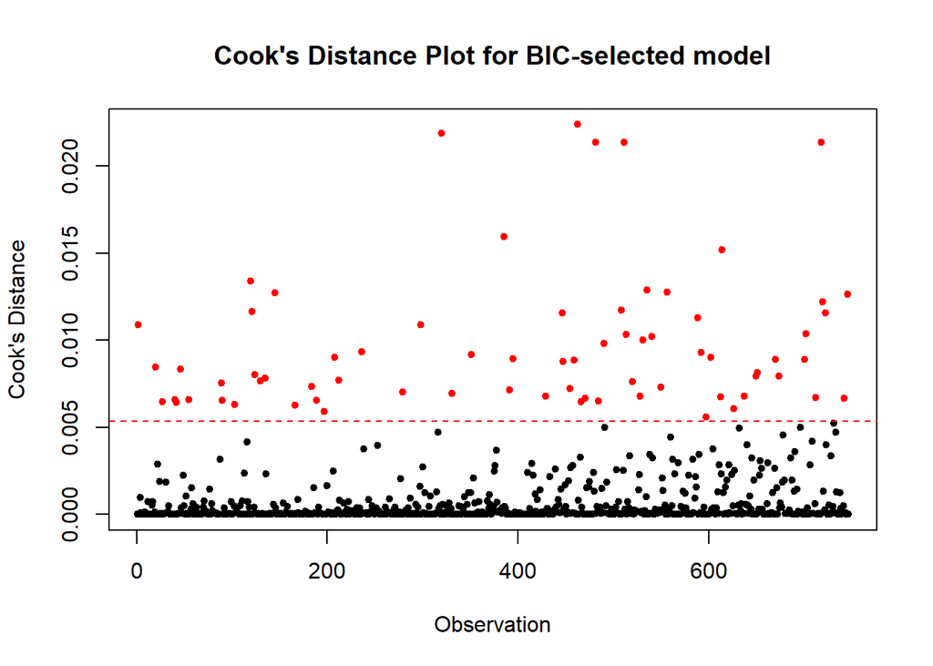

```r
# Plot Cook's distance
plot(cd.bic, pch = 20, col = ifelse(influential_pts, "red", "black"),
     main = "Cook's Distance Plot for BIC-selected model", xlab = "Observation", ylab = "Cook's Distance")

# Adding a horizontal line at Cook's distance cutoff (4/n)
abline(h = 4/length(cd.bic), col = "red", lty = 2)
```

#### Cross Validation & Calibration plot

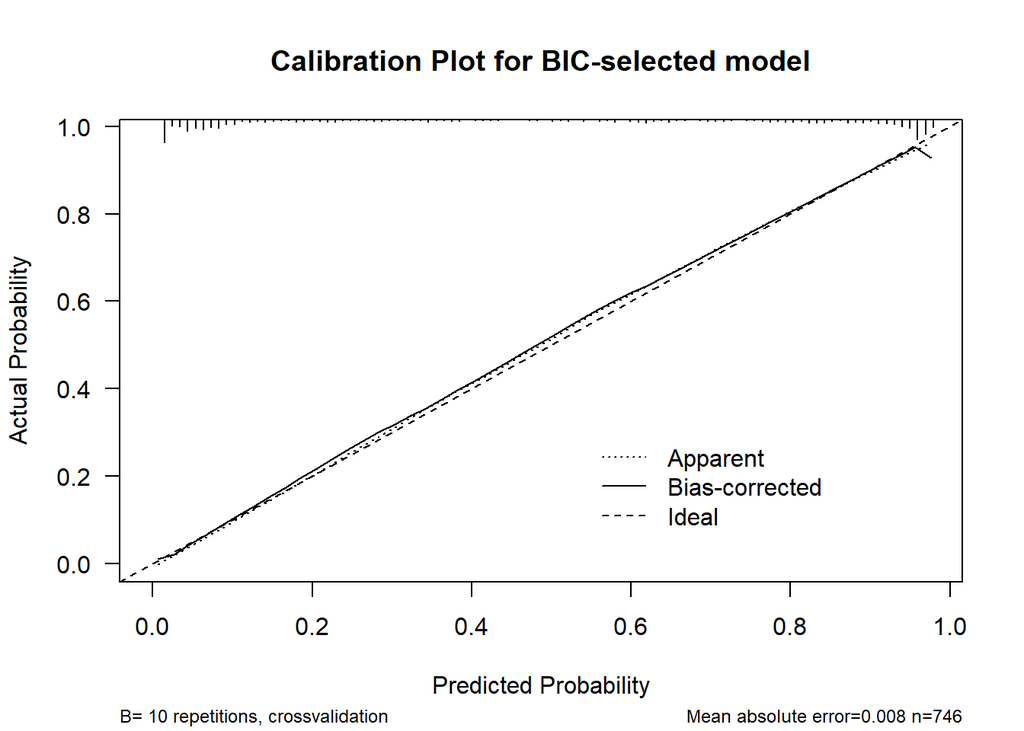

```
##
## n=746   Mean absolute error=0.008   Mean squared error=0.00014
## 0.9 Quantile of absolute error=0.019
```

```r
library(rms)

## Fit the model with lrm from rms package ##
lrm.bic <- lrm(HeartDisease ~ ., data = df[,which(colnames(df) %in% c(select_var_bic, "HeartDisease"))], x =TRUE, y = TRUE, model= T)

 # model calibration
cross.calib.bic <- calibrate(lrm.bic, method="crossvalidation", B=10)
plot(cross.calib.bic, las=1, xlab = "Predicted Probability",
     main = "Calibration Plot for BIC-selected model")
```

#### ROC Curve

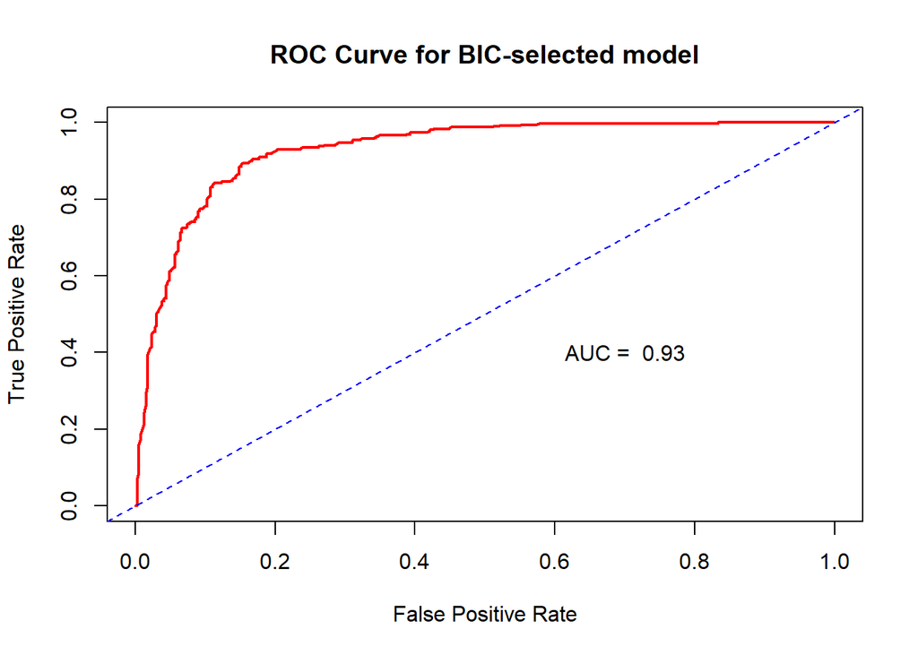

```r
library(pROC)
p.bic <- predict(lrm.bic, type = "fitted")

roc.bic <- roc(df$HeartDisease ~ p.bic)
## The True Positive Rate ##
TPR.bic <- roc.bic$sensitivities
## The False Positive Rate ##
FPR.bic <- 1 - roc.bic$specificities

plot(FPR.bic, TPR.bic, xlim = c(0,1), ylim = c(0,1), type = 'l', lty = 1, lwd = 2,col = 'red', xlab = "False Positive Rate", ylab = "True Positive Rate",
     main = "ROC Curve for BIC-selected model")
abline(a = 0, b = 1, lty = 2, col = 'blue')
text(0.7,0.4,label = paste("AUC = ", round(auc(roc.bic),2)))
```

```r
auc(roc.bic)
```

```
## Area under the curve: 0.9294
```